# Clustering Tracks with CelltrackR

Inge Wortel

2019-06-07

# Introduction

To group tracks with similar properties, one can in principle perform any clustering method of interest on a *feature matrix* of quantification metrics for each track in the dataset. The package comes with three convenience functions – `getFeatureMatrix()`,`trackFeatureMap()`, and `clusterTracks()` – to easily compute several metrics on all tracks at once, visualize them in 2 dimensions, and to cluster tracks accordingly. This tutorial shows how to use these functions to explore heterogeneity in a track dataset.

# Datasets

First load the package:

```r
library( celltrackR )
```

The package contains a dataset of T cells imaged in a mouse peripheral lymph node using two photon microscopy. We will here use this dataset as an example of how to perform quality control.

```r
str( TCells, list.len = 2 )
```

```
#> List of 22
#>  $ 0 : num [1:11, 1:4] 0 27.8 55.5 83.3 111.1 ...
#>   ..- attr(*, "dimnames")=List of 2
#>   .. ..$ : chr [1:11] "1" "2" "3" "4" ...
#>   .. ..$ : chr [1:4] "t" "x" "y" "z"
#>  $ 1 : num [1:11, 1:4] 0 27.8 55.5 83.3 111.1 ...
#>   ..- attr(*, "dimnames")=List of 2
#>   .. ..$ : chr [1:11] "1" "2" "3" "4" ...
#>   .. ..$ : chr [1:4] "t" "x" "y" "z"
#>   [list output truncated]
#>  - attr(*, "class")= chr "tracks"
```

Each element in this list is a track from a single cell, consisting of a matrix with $(x,y,z)$ coordinates and the corresponding measurement timepoints:

```r
head( TCells[[1]] )
```

```
#>         t       x       y    z
#> 1   0.000 132.521 118.692 8.75
#> 2  27.781 133.909 118.700 8.75
#> 3  55.484 131.763 118.129 6.25
#> 4  83.296 133.161 117.903 6.25
#> 5 111.093 131.530 117.894 6.25
#> 6 138.906 132.229 117.665 6.25
```

Similarly, we will also use the `BCells` and `Neutrophils` data:

```r
str( BCells, list.len = 2 )
```

```
#> List of 24
#>  $ 0 : num [1:18, 1:4] 27.8 55.5 83.3 111.1 138.9 ...
#>   ..- attr(*, "dimnames")=List of 2
#>   .. ..$ : chr [1:18] "1" "2" "3" "4" ...
#>   .. ..$ : chr [1:4] "t" "x" "y" "z"
#>  $ 1 : num [1:30, 1:4] 0 27.8 55.5 83.3 111.1 ...
#>   ..- attr(*, "dimnames")=List of 2
#>   .. ..$ : chr [1:30] "19" "20" "21" "22" ...
#>   .. ..$ : chr [1:4] "t" "x" "y" "z"
#>   [list output truncated]
#>  - attr(*, "class")= chr "tracks"
```

```r
str( Neutrophils, list.len = 2 )
```

```
#> List of 10
#>  $ 0: num [1:25, 1:4] 28.2 56.4 84.6 113.1 141.3 ...
#>   ..- attr(*, "dimnames")=List of 2
#>   .. ..$ : chr [1:25] "1" "2" "3" "4" ...
#>   .. ..$ : chr [1:4] "t" "x" "y" "z"
#>  $ 1: num [1:22, 1:4] 0 28.2 56.4 84.6 113.1 ...
#>   ..- attr(*, "dimnames")=List of 2
#>   .. ..$ : chr [1:22] "26" "27" "28" "29" ...
#>   .. ..$ : chr [1:4] "t" "x" "y" "z"
#>   [list output truncated]
#>  - attr(*, "class")= chr "tracks"
```

Combine them in a single dataset, where labels also indicate celltype:

```r
T2 <- TCells
names(T2) <- paste0( "T", names(T2) )
tlab <- rep( "T", length(T2) )

B2 <- BCells
names(B2) <- paste0( "B", names(B2) )
blab <- rep( "B", length(B2) )

N2 <- Neutrophils
names(N2) <- paste0( "N", names(Neutrophils) )
nlab <- rep( "N", length( N2) )

all.tracks <- c( T2, B2, N2 )
real.celltype <- c( tlab, blab, nlab )
```

# 1 Extracting a feature matrix

Using the function `getFeatureMatrix()`, we can quickly apply several quantification measures to all data at once (see `?TrackMeasures` for an overview of measures we can compute):

```r
m <- getFeatureMatrix( all.tracks,
                       c(speed, meanTurningAngle,
                         outreachRatio, squareDisplacement) )

# We get a matrix with a row per track and one column for each metric:
head(m)
```

```
#>          [,1]      [,2]      [,3]        [,4]
#> T0 0.04111888 2.5748446 0.2458866    7.389989
#> T1 0.16407805 0.6500093 0.8004166 1330.130666
#> T2 0.14649521 1.0933954 0.4130841 1590.395966
#> T3 0.12828778 1.2933856 0.4102647 2994.020167
#> T4 0.08589151 1.4616603 0.5382724  695.435841
#> T5 0.26304168 0.7005672 0.4257547 1636.184659
```

We can use this matrix to explore relationships between different metrics. For example, we can observe a negative correlation between speed and mean turning angle:

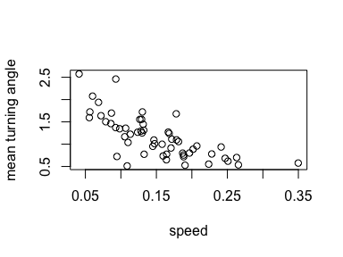

```r
plot( m, xlab = "speed", ylab = "mean turning angle" )
```

# 2 Dimensionality reduction methods: PCA, MDS, and UMAP

When using more than two metrics at once to quantify track properties, it becomes hard to visualize which tracks are similar to each other. Like with single-cell data, dimensionality reduction methods can help visualize high-dimensional track feature datasets. The function `trackFeatureMap()` is a wrapper method that helps to quickly visualize data using three popular methods: principal component analysis (PCA), multidimensional scaling (MDS), and uniform manifold approximate and projection (UMAP). The function `trackFeatureMap()` can be used for a quick visualization of data, or return the coordinates in the new axis system if the argument `return.mapping=TRUE`.

### 1.1 PCA

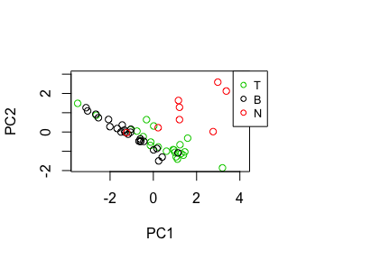

```r
pca <- trackFeatureMap( all.tracks,
               c(speed,meanTurningAngle,squareDisplacement,
                 maxDisplacement,outreachRatio ), method = "PCA",
               labels = real.celltype, return.mapping = TRUE )
```

We can then inspect the data stored in `pca`. This reveals, for example, that the first principal component is correlated with speed:

```r
pc1 <- pca[,1]
pc2 <- pca[,2]
track.speed <- sapply( all.tracks, speed )
cor.test( pc1, track.speed )
```

```
#>
#>  Pearson's product-moment correlation
#>
#> data:  pc1 and track.speed
#> t = 9.2314, df = 54, p-value = 1.072e-12
#> alternative hypothesis: true correlation is not equal to 0
#> 95 percent confidence interval:
#>  0.6540020 0.8669588
#> sample estimates:
#>       cor
#> 0.7823818
```

See `?prcomp` for details on how principal components are computed, and for further arguments that can be passed on to `trackFeatureMap()`.

### 1.2 MDS

Another popular method for visualization is multidimensional scaling (MDS), which is also supported by `trackFeatureMap()`:

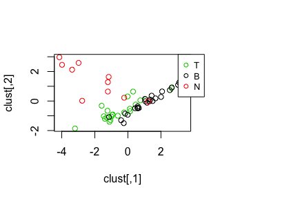

```r
trackFeatureMap( all.tracks,
               c(speed,meanTurningAngle,squareDisplacement,maxDisplacement,
                 outreachRatio ), method = "MDS",
               labels = real.celltype )
```

Internally, `trackFeatureMap()` computes a distance matrix using `dist()` and then applies MDS using `cmdscale()`. See the documentation of `cmdscale` for details and further arguments that can be passed on via `trackFeatureMap()`.

### 1.3 UMAP

Uniform manifold approximate and projection (UMAP) is another powerful method to explore structure in high-dimensional datasets. `trackFeatureMap()` supports visualization of tracks in a UMAP. Note that this option requires the `uwot` package. Please install this package first using `install.packages("uwot")`.

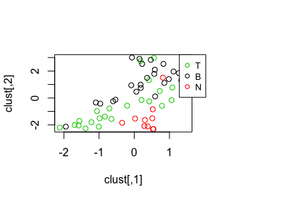

```r
trackFeatureMap( all.tracks,
        c(speed,meanTurningAngle,squareDisplacement,
          maxDisplacement,outreachRatio ), method = "UMAP",
          labels = real.celltype )
```

# 3 Clustering: hierarchical clustering and k-means

To go beyond visualizing similar and dissimilar tracks using multiple track features, `clusterTracks()` supports the explicit grouping of tracks into clusters using two common methods: hierarchical and k-means clustering.

### 3.1 Hierarchical clustering

Hierarchical clustering is performed by calling `hclust()` on a distance matrix computed via `dist()` on the feature matrix:

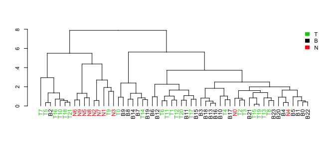

```r
clusterTracks( all.tracks,
               c(speed,meanTurningAngle,squareDisplacement,maxDisplacement,
                 outreachRatio ), method = "hclust", labels = real.celltype )
```

See methods `dist()` and `hclust()` for details.

### 3.2 K-means clustering

Secondly, `clusterTracks()` also supports k-means clustering of tracks. Note that this requires an extra argument `centers` that is passed on to the `kmeans()` function and specifies the number of clusters to make. In this case, let’s use three clusters because we have three celltypes:

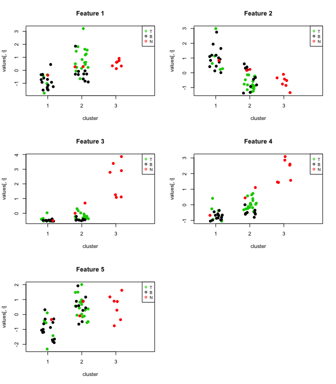

```r
clusterTracks( all.tracks,
               c(speed,meanTurningAngle,squareDisplacement,maxDisplacement,
                 outreachRatio ), method = "kmeans",
               labels = real.celltype, centers = 3 )
```

In these plots, we see the value of each feature in the feature matrix plotted for the different clusters, whereas the color indicates the “real” celltype the track came from.